# Exploratory And Statistical Analysis - Dataset of 30,000 Products From Amazon

## DF 5

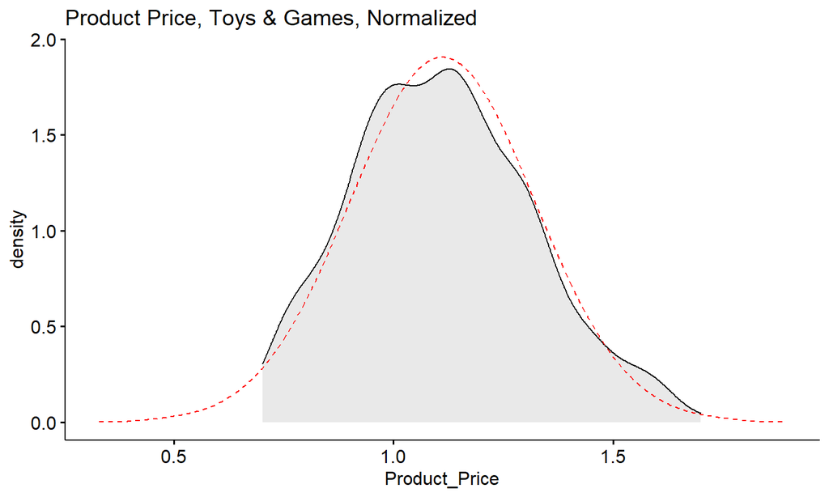

[figure not shown]

## DF 6

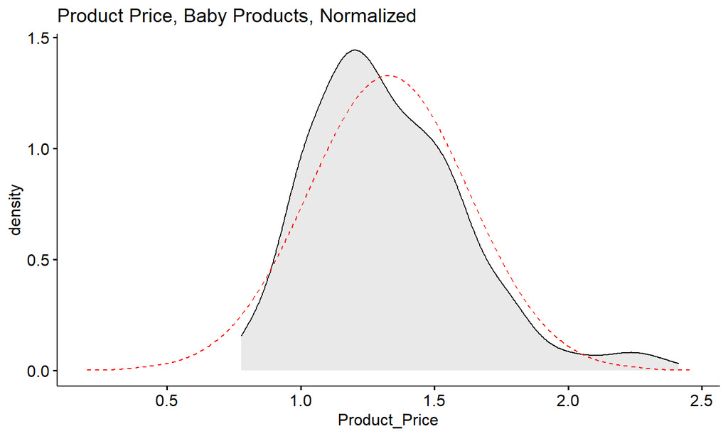

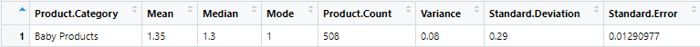

## DF 7

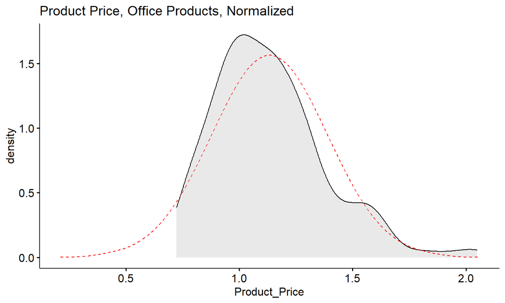

[figure not shown]

## DF 9

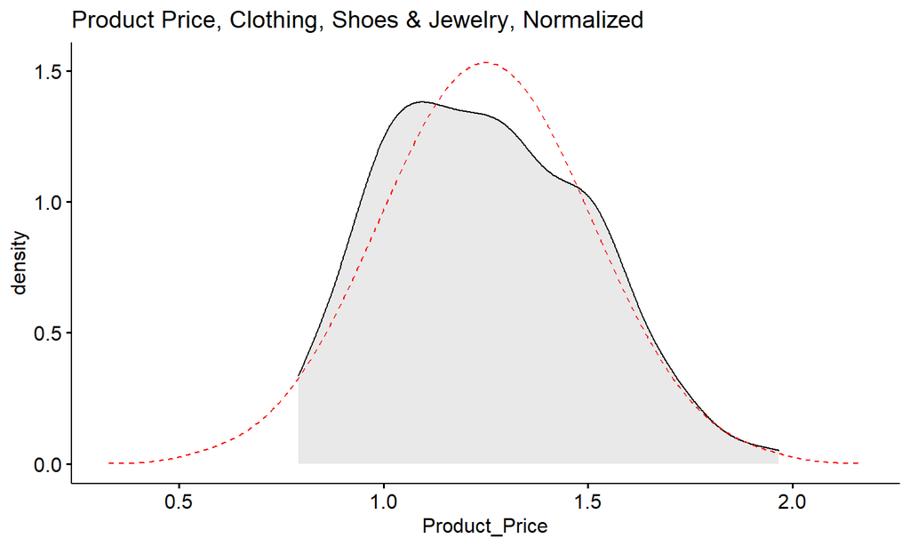

[figure not shown]

# PART B - CONFIDENCE INTERVAL/HYPOTHESIS TESTING

# PART 6 - PERFORMING CONFIDENCE INTERVAL TESTING

- DETERMINE HOW STATISTICALLY CLOSE THE SAMPLE MEAN IS TO THE POPULATION MEAN
- WHETHER OR NOT THE DIFFERENCE BETWEEN THE MEANS OF EACH PRODUCT CATEGORY IS STATISTICALLY SIGNIFICANT

# VALUES OF CONFIDENCE INTERVAL OF SAMPLE MEAN OF PRODUCT PRICE, 95/99% CONFIDENCE

## ALPHA

```
alpha <- 0.05
alpha_99 <- 0.01
```

## DEGREES OF FREEDOM

```
degrees_freedom_1 <- count1_log - 1
degrees_freedom_2 <- count2_log - 1
degrees_freedom_3 <- count3_log - 1
degrees_freedom_4 <- count4_log - 1
degrees_freedom_5 <- count5_log - 1
degrees_freedom_6 <- count6_log - 1
degrees_freedom_7 <- count7_log - 1
degrees_freedom_9 <- count9_log - 1
```

## T-SCORE

```
t_score_1 <- qt(p=alpha/2, df=degrees_freedom_1, lower.tail = FALSE)
t_score_2 <- qt(p=alpha/2, df=degrees_freedom_2, lower.tail = FALSE)
t_score_3 <- qt(p=alpha/2, df=degrees_freedom_3, lower.tail = FALSE)
t_score_4 <- qt(p=alpha/2, df=degrees_freedom_4, lower.tail = FALSE)
t_score_5 <- qt(p=alpha/2, df=degrees_freedom_5, lower.tail = FALSE)
t_score_6 <- qt(p=alpha/2, df=degrees_freedom_6, lower.tail = FALSE)
t_score_7 <- qt(p=alpha/2, df=degrees_freedom_7, lower.tail = FALSE)
t_score_9 <- qt(p=alpha/2, df=degrees_freedom_9, lower.tail = FALSE)

t_score_1_99 <- qt(p=alpha_99/2, df=degrees_freedom_1, lower.tail = FALSE)
t_score_2_99 <- qt(p=alpha_99/2, df=degrees_freedom_2, lower.tail = FALSE)
t_score_3_99 <- qt(p=alpha_99/2, df=degrees_freedom_3, lower.tail = FALSE)
t_score_4_99 <- qt(p=alpha_99/2, df=degrees_freedom_4, lower.tail = FALSE)
t_score_5_99 <- qt(p=alpha_99/2, df=degrees_freedom_5, lower.tail = FALSE)
t_score_6_99 <- qt(p=alpha_99/2, df=degrees_freedom_6, lower.tail = FALSE)
t_score_7_99 <- qt(p=alpha_99/2, df=degrees_freedom_7, lower.tail = FALSE)
t_score_9_99 <- qt(p=alpha_99/2, df=degrees_freedom_9, lower.tail = FALSE)
```

## MARGIN OF ERROR

```
margin_error_1 <- t_score_1 * se_ads_1
margin_error_2 <- t_score_2 * se_ads_2
margin_error_3 <- t_score_3 * se_ads_3
margin_error_4 <- t_score_4 * se_ads_4
margin_error_5 <- t_score_5 * se_ads_5
margin_error_6 <- t_score_6 * se_ads_6
margin_error_7 <- t_score_7 * se_ads_7
margin_error_9 <- t_score_9 * se_ads_9

margin_error_1_99  <- t_score_1_99  * se_ads_1
margin_error_2_99  <- t_score_2_99  * se_ads_2
margin_error_3_99  <- t_score_3_99  * se_ads_3
margin_error_4_99  <- t_score_4_99  * se_ads_4
margin_error_5_99  <- t_score_5_99  * se_ads_5
margin_error_6_99  <- t_score_6_99  * se_ads_6
margin_error_7_99  <- t_score_7_99  * se_ads_7
margin_error_9_99  <- t_score_9_99  * se_ads_9
```

## LOWER/UPPER BOUNDS

```
lower_bound_1 <- mean1_log - margin_error_1
upper_bound_1 <- mean1_log + margin_error_1

lower_bound_2 <- mean2_log - margin_error_2
upper_bound_2 <- mean2_log + margin_error_2

lower_bound_3 <- mean3_log - margin_error_3
upper_bound_3 <- mean3_log + margin_error_3

lower_bound_4 <- mean4_log - margin_error_4
upper_bound_4 <- mean4_log + margin_error_4

lower_bound_5 <- mean5_log - margin_error_5
upper_bound_5 <- mean5_log + margin_error_5

lower_bound_6 <- mean6_log - margin_error_6
upper_bound_6 <- mean6_log + margin_error_6

lower_bound_7 <- mean7_log - margin_error_7
upper_bound_7 <- mean7_log + margin_error_7

lower_bound_9 <- mean9_log - margin_error_9
upper_bound_9 <- mean9_log + margin_error_9

lower_bound_1_99  <- mean1_log - margin_error_1_99
upper_bound_1_99  <- mean1_log + margin_error_1_99

lower_bound_2_99  <- mean2_log - margin_error_2_99
upper_bound_2_99  <- mean2_log + margin_error_2_99

lower_bound_3_99  <- mean3_log - margin_error_3_99
upper_bound_3_99  <- mean3_log + margin_error_3_99

lower_bound_4_99  <- mean4_log - margin_error_4_99
upper_bound_4_99  <- mean4_log + margin_error_4_99

lower_bound_5_99  <- mean5_log - margin_error_5_99
upper_bound_5_99  <- mean5_log + margin_error_5_99

lower_bound_6_99  <- mean6_log - margin_error_6_99
upper_bound_6_99  <- mean6_log + margin_error_6_99

lower_bound_7_99  <- mean7_log - margin_error_7_99
upper_bound_7_99  <- mean7_log + margin_error_7_99

lower_bound_9_99  <- mean9_log - margin_error_9_99
upper_bound_9_99  <- mean9_log + margin_error_9_99
```

## DATAFRAMES FOR ALL DATA

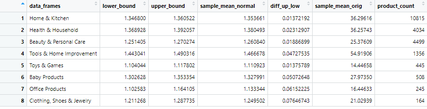

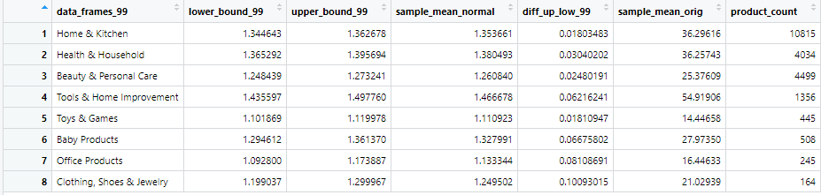

## CONFIDENCE INTERVAL PLOTS

```
CI_95_PLOT <- plotCI(x=CIs_ADS_95[,4],ui=CIs_ADS_95[,3],li=CIs_ADS_95[,2], main = "CI, 95%", xlab = "Dataframes 1-7,9 (8 = 9)", ylab= "mean")
CI_99_PLOT <- plotCI(x=CIs_ADS_99[,4],ui=CIs_ADS_99[,3],li=CIs_ADS_99[,2], main = "CI, 99%", xlab = "Dataframes 1-7,9 (8 = 9)", ylab= "mean")
```

## CONFIDENCE INTERVAL PLOT – 95% CONFIDENCE

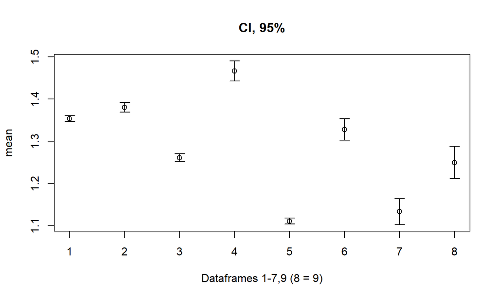

## CONFIDENCE INTERVAL PLOT – 99% CONFIDENCE

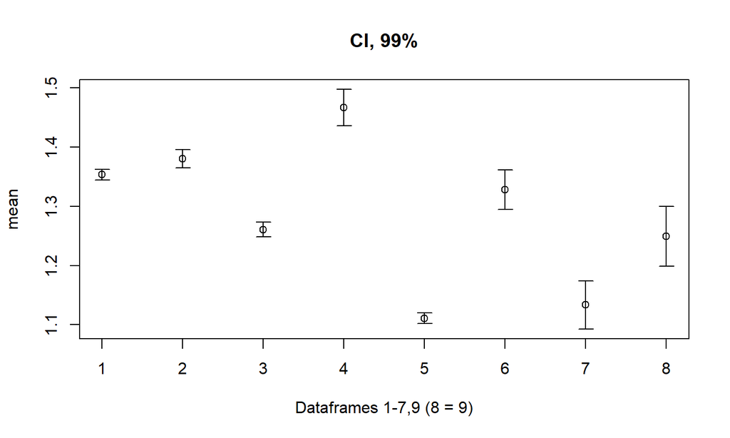

## MOVING FORWARD TO COMPARE IF THE DIFFERENCE IS STATISTICALLY SIGNIFICANT

- THE DATAFRAMES THAT HAVE THE SMALLEST GAP BETWEEN THE LOWER/UPPER BOUND FOR THE MEAN
- THE DATAFRAMES THAT HAVE THE HIGHEST PRODUCT COUNTS

> DF1 DF2 DF3

# BOUND NORMAL VALUES TO DFS

```
names(ads_1_log) <- "Product_Price_Norm"
names(ads_2_log) <- "Product_Price_Norm"
names(ads_3_log) <- "Product_Price_Norm"

ads_1_df_norm_values <- cbind.data.frame(amazon_dataset_1_removed_outliers, ads_1_log)
ads_2_df_norm_values <- cbind.data.frame(amazon_dataset_2_removed_outliers, ads_2_log)
ads_3_df_norm_values <- cbind.data.frame(amazon_dataset_3_removed_outliers, ads_3_log)
```

## F TEST TO CHECK IF VARIANCE IS EQUAL TO PERFORM STUDENT T TEST

- IN ORDER TO PERFORM A STUDENT T TEST, THE DIFFERENCE IN THE VARIANCE MUST = 0

```
ads_1_log_unlist <- unlist(ads_1_log)
ads_2_log_unlist <- unlist(ads_2_log)
ads_3_log_unlist <- unlist(ads_3_log)

var_test_1and2 <- var.test(ads_1_log_unlist ,ads_2_log_unlist, alternative = "two.sided")
var_test_2and3 <- var.test(ads_2_log_unlist ,ads_3_log_unlist, alternative = "two.sided")
var_test_1and3 <- var.test(ads_1_log_unlist ,ads_3_log_unlist, alternative = "two.sided")
```

# F TEST VALUES

## VARIANCE MEAN 1 AND MEAN 2

F test to compare two variances

data: ads_1_log_unlist and ads_2_log_unlist F = 0.94399, num df = 10814, denom df = 4033, p-value = 0.02625 alternative hypothesis: true ratio of variances is not equal to 1 95 percent confidence interval: 0.8966503 0.9932285 sample estimates: ratio of variances 0.9439905

F test to compare two variances

data: ads_1_log_unlist and ads_3_log_unlist F = 1.2717, num df = 10814, denom df = 4498, p-value < 2.2e-16 alternative hypothesis: true ratio of variances is not equal to 1 95 percent confidence interval: 1.210346 1.335457 sample estimates: ratio of variances 1.271685

F test to compare two variances

data: ads_2_log_unlist and ads_3_log_unlist F = 1.3471, num df = 4033, denom df = 4498, p-value < 2.2e-16 alternative hypothesis: true ratio of variances is not equal to 1 95 percent confidence interval: 1.268601 1.430678 sample estimates: ratio of variances 1.347137

## PERFORM WELCH’S T TEST INSTEAD

- H-NULL TRUE DIFFERENCE IN MEANS = 0
- H-ALT TRUE DIFFERENCE IN MEANS =/= 0
- ALPHA IS 0.05

```
welch_means1and2 <- t.test(ads_1_log_unlist, ads_2_log_unlist)
welch_means2and3 <- t.test(ads_2_log_unlist, ads_3_log_unlist)
welch_means1and3 <- t.test(ads_1_log_unlist, ads_3_log_unlist)

print(welch_means1and2$p.value)
print(welch_means2and3$p.value)
print(welch_means1and3$p.value)
```

## PERFORM WELCH’S T TEST INSTEAD

[1] 9.23992e-05

[1] 7.512562e-55

[1] 3.53086e-54

# PART 7 - IS THERE A CORRELATION BETWEEN PRODUCT RATING AND PRODUCT PRICE?

## OBSERVED HISTOGRAM – DECIDED TO REMOVE LINES WITH 0 REVIEWS

```
product_rating_hist_1 <- ggplot(ads_1_df_norm_values, aes(x=Product_Rating)) +
                            geom_histogram(binwidth = 1, color = "white")
```

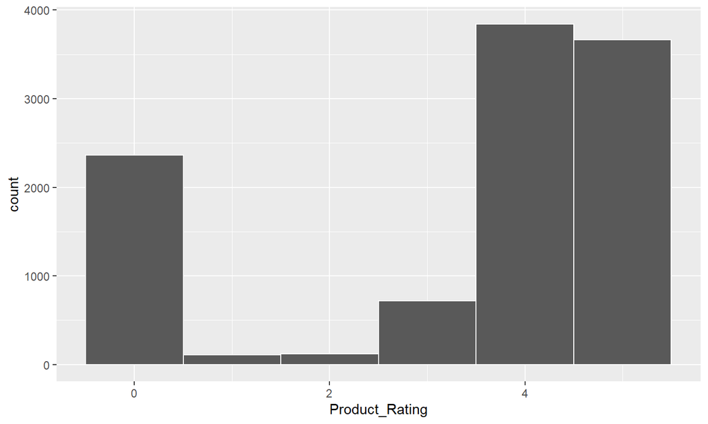

## LOOKING AT COUNT OF EACH RATING

```
product_rating_1 <- ads_1_df_norm_values %>%
                      group_by(product_rating = ads_1_df_norm_values$Product_Rating) %>%
                      tally()
```

[figure not shown]

## FILTERED OUT PRODUCT WITH NO REVIEWS

```
ads_1_df_reviewed <- ads_1_df_norm_values[!(ads_1_df_norm_values$Product_Reviews_Count == 0),]
ads_2_df_reviewed <- ads_2_df_norm_values[!(ads_2_df_norm_values$Product_Reviews_Count == 0),]
ads_3_df_reviewed <- ads_3_df_norm_values[!(ads_3_df_norm_values$Product_Reviews_Count == 0),]
```

## REPLOTTED HISTOGRAMS

```
product_rating_hist_1_rvd <- ggplot(ads_1_df_reviewed, aes(x=Product_Rating)) +
                              geom_histogram(binwidth = 0.25, color = "white")

product_rating_hist_2_rvd <- ggplot(ads_2_df_reviewed, aes(x=Product_Rating)) +
                              geom_histogram(binwidth = 0.25, color = "white")

product_rating_hist_3_rvd <- ggplot(ads_3_df_reviewed, aes(x=Product_Rating)) +
                              geom_histogram(binwidth = 0.25, color = "white")
```

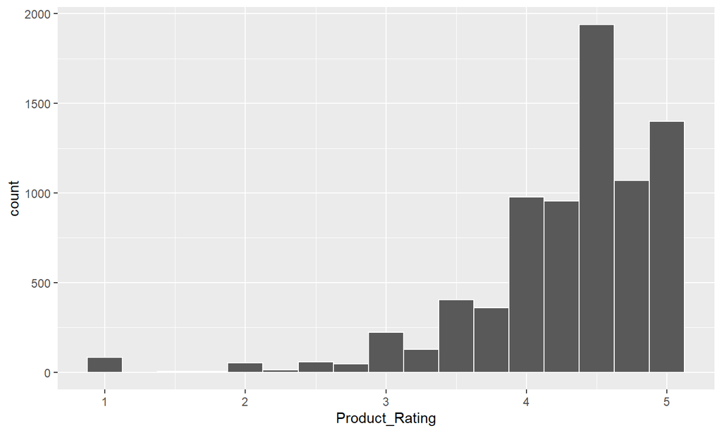

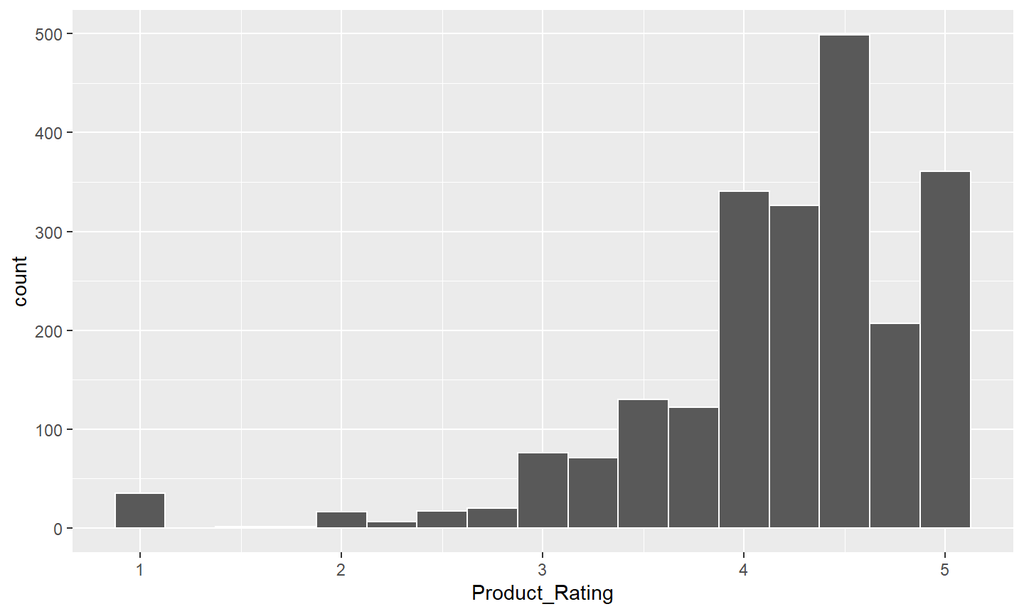

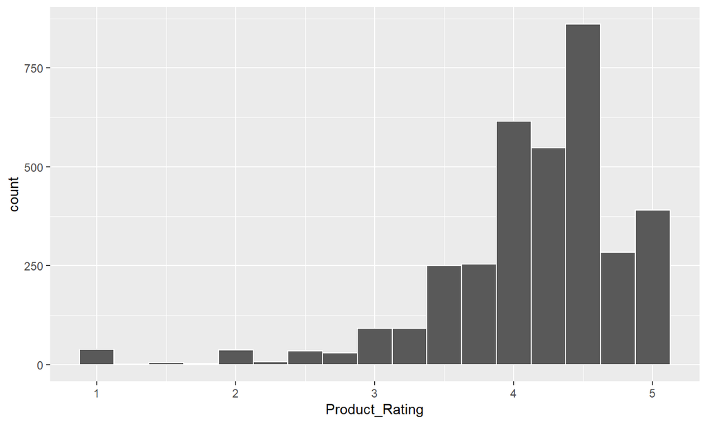

## NORMALIZE THE VALUES USING LOG10 AND LOOKED AT DENSITY OF PRODUCT RATING

```
rating_normal_1 <- log10(ads_1_df_reviewed$Product_Rating)
rating_normal_2 <- log10(ads_2_df_reviewed$Product_Rating)
rating_normal_3 <- log10(ads_3_df_reviewed$Product_Rating)

ads_1_df_reviewed <- cbind.data.frame(ads_1_df_reviewed, rating_normal_1)
ads_2_df_reviewed <- cbind.data.frame(ads_2_df_reviewed, rating_normal_2)
ads_3_df_reviewed <- cbind.data.frame(ads_3_df_reviewed, rating_normal_3)

ads_1_rating_log_density <- ggdensity(rating_normal_1,fill = "lightgray", title = "Product Rating, Home & Kitchen") +
                                                    stat_overlay_normal_density(color = "red", linetype = "dashed")
ads_2_rating_log_density <- ggdensity(rating_normal_2,fill = "lightgray", title = "Product Rating, Health & Household") +
                                                    stat_overlay_normal_density(color = "red", linetype = "dashed")
ads_3_rating_log_density <- ggdensity(rating_normal_3,fill = "lightgray", title = "Product Rating, Beauty And Personal Care") +
                                                   stat_overlay_normal_density(color = "red", linetype = "dashed")
```

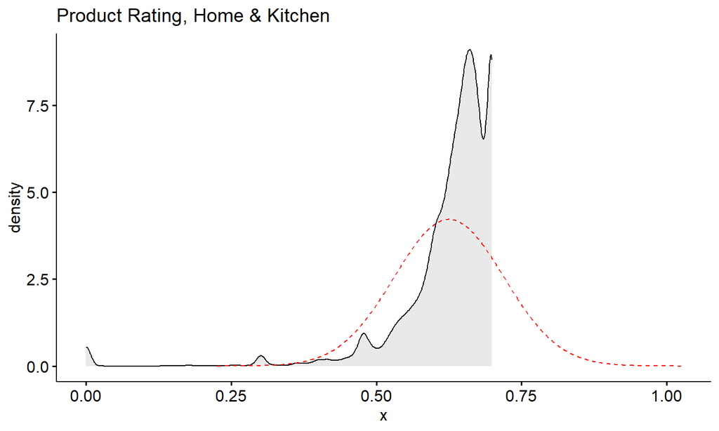

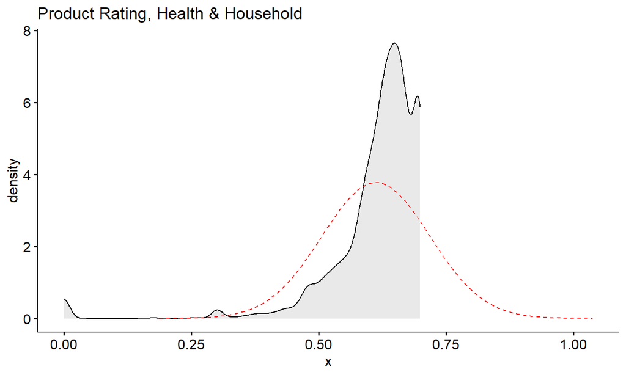

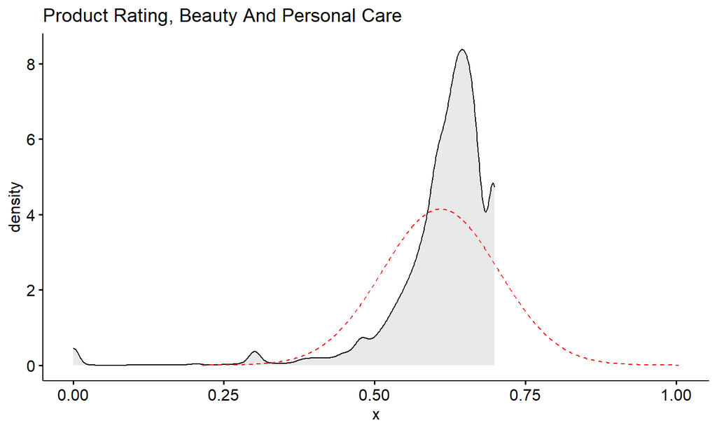

## RAN COORELATION COEFFICENT BETWEEN PRODUCT PRICE AND PRODUCT RATING

```
cor_ads_1 <- cor(ads_1_df_reviewed$Product_Price, ads_1_df_reviewed$Product_Rating)
cor_ads_2 <- cor(ads_2_df_reviewed$Product_Price, ads_2_df_reviewed$Product_Rating)
cor_ads_3 <- cor(ads_3_df_reviewed$Product_Price, ads_3_df_reviewed$Product_Rating)

cor_ads_1_norm <- cor(ads_1_df_reviewed$Product_Price_Norm, ads_1_df_reviewed$rating_normal_1)
cor_ads_2_norm <- cor(ads_2_df_reviewed$Product_Price_Norm, ads_2_df_reviewed$rating_normal_2)
cor_ads_3_norm <- cor(ads_3_df_reviewed$Product_Price_Norm, ads_3_df_reviewed$rating_normal_3)

print(cor_ads_1)
print(cor_ads_1_norm)
print(cor_ads_2)
print(cor_ads_2_norm)
print(cor_ads_3)
print(cor_ads_3_norm)
```

## COORELATION COEFFICENTS BETWEEN PRODUCT PRICE AND PRODUCT RATING

COR ADS 1 (BOTH REGULAR AND NORMALIZED VALUES)

> [1] -0.03021033 [1] -0.01678979

COR ADS 2 (BOTH REGULAR AND NORMALIZED VALUES)

> [1] -0.0418366 [1] -0.03605427

COR ADS 3 (BOTH REGULAR AND NORMALIZED VALUES)

> [1] -0.02456391 [1] 0.006036672

## COORELATION COEFFICENTS BETWEEN PRODUCT PRICE AND PRODUCT RATING

- COORELATION COEEFICENT SHOWS NO/NEGLIBLE RELATIONSHIP BETWEEN PRODUCT PRICE AND PRODUCT RATING

# PART 9 - IS THERE A CORRELATION BETWEEN PRODUCT PRICE AND PRODUCT RANKING?

## CREATED NUMERICAL VALUES FOR INDIVIDUAL CATEGORY RANKING AND THE OVERALL PRODUCT CATEGORY RANKING

-WROTE CSVS FOR DF 1,2, & 3 WITHOUT OUTLIERS TO DELIMIT THE BSR VALUES IN EXCEL

```
write.csv(amazon_dataset_1_removed_outliers, "G:\\My Drive\\1_SPRING 2021\\2_STATISTICS AND ANALYSIS\\Final Project\\ADS_123_CSV\\ads_ros_1.csv", row.names = FALSE)
write.csv(amazon_dataset_2_removed_outliers, "G:\\My Drive\\1_SPRING 2021\\2_STATISTICS AND ANALYSIS\\Final Project\\ADS_123_CSV\\ads_ros_2.csv", row.names = FALSE)
write.csv(amazon_dataset_3_removed_outliers, "G:\\My Drive\\1_SPRING 2021\\2_STATISTICS AND ANALYSIS\\Final Project\\ADS_123_CSV\\ads_ros_3.csv", row.names = FALSE)
```

## LOAD EXCEL FILES

```
setwd("G:\\My Drive\\1_SPRING 2021\\2_STATISTICS AND ANALYSIS\\Final Project\\ADS_123_CSV")

bsr_cleaned_files <- as.vector(list.files(path = "G:\\My Drive\\1_SPRING 2021\\2_STATISTICS AND ANALYSIS\\Final Project\\ADS_123_CSV", pattern = "*.xlsx"))

view(bsr_cleaned_files)

amazon_dataset_1_delim_bsr <- as.data.frame(lapply(bsr_cleaned_files[1], read_xlsx))
amazon_dataset_2_delim_bsr <- as.data.frame(lapply(bsr_cleaned_files[2], read_xlsx))
amazon_dataset_3_delim_bsr <- as.data.frame(lapply(bsr_cleaned_files[3], read_xlsx))

amazon_dataset_1_delim_bsr <- select(amazon_dataset_1_delim_bsr,, -37:-47)
amazon_dataset_2_delim_bsr <- select(amazon_dataset_2_delim_bsr,, -37:-42)
amazon_dataset_3_delim_bsr <- select(amazon_dataset_3_delim_bsr,, -37:-38)

names_adsbrs2 <- names(amazon_dataset_2_delim_bsr)
names_adsbrs2[32] <- "BSR_1_CAT"
setnames(amazon_dataset_2_delim_bsr, old = names(amazon_dataset_2_delim_bsr), new = names_adsbrs2)
```

## SUBSET INTO 1 AND 2 RANKINGS

- DF1

```
amazon_dataset_1_delim_bsr_1st <- select(amazon_dataset_1_delim_bsr,, -31:-36)
amazon_dataset_1_delim_bsr_2nd <- select(amazon_dataset_1_delim_bsr,,-29:-30)
amazon_dataset_1_delim_bsr_2nd <- select(amazon_dataset_1_delim_bsr_2nd,,-31:-34)
amazon_dataset_1_delim_bsr_3rd <- select(amazon_dataset_1_delim_bsr,,-35:-36)
amazon_dataset_1_delim_bsr_3rd <- select(amazon_dataset_1_delim_bsr_3rd,,-29:-32)
```

- DF2

```
amazon_dataset_2_delim_bsr_1st <- select(amazon_dataset_2_delim_bsr,, -33:-36)
amazon_dataset_2_delim_bsr_2nd <- select(amazon_dataset_2_delim_bsr,, -35:-36)
amazon_dataset_2_delim_bsr_2nd <- select(amazon_dataset_2_delim_bsr_2nd,, -31:-32)
```

- DF3

```
amazon_dataset_3_delim_bsr_1st <- select(amazon_dataset_3_delim_bsr,, -33:-36)
amazon_dataset_3_delim_bsr_2nd <- select(amazon_dataset_3_delim_bsr,, -35:-36)
amazon_dataset_3_delim_bsr_2nd <- select(amazon_dataset_3_delim_bsr_2nd,, -31:-32)
```

## DROP NA VALUES

```
amazon_dataset_1_delim_bsr_1st <- drop_na(amazon_dataset_1_delim_bsr_1st, "BSR_1_CAT")
amazon_dataset_1_delim_bsr_2nd <- drop_na(amazon_dataset_1_delim_bsr_2nd, "BSR_1.2_CAT")
amazon_dataset_1_delim_bsr_3rd <- drop_na(amazon_dataset_1_delim_bsr_3rd, "BSR_2_CAT")

amazon_dataset_2_delim_bsr_1st <- drop_na(amazon_dataset_2_delim_bsr_1st, "BSR_1_CAT")
amazon_dataset_2_delim_bsr_2nd <- drop_na(amazon_dataset_2_delim_bsr_2nd, "BSR_2_CAT")

amazon_dataset_3_delim_bsr_1st <- drop_na(amazon_dataset_3_delim_bsr_1st, "BSR_1_CAT")
amazon_dataset_3_delim_bsr_2nd <- drop_na(amazon_dataset_3_delim_bsr_2nd, "BSR_2_CAT")
```

# SIMPLE PLOTS // COR.COE

## ADS 1_1

```
product_rank_hist <- ggplot(amazon_dataset_1_delim_bsr_1st, aes(x=BSR_1_VALUE)) +
                                geom_histogram(binwidth = 100000, color = "white")
print(product_rank_hist)

product_rank_dot_2_1 <- plot(Product_Price ~ BSR_1_VALUE, data = amazon_dataset_2_delim_bsr_1st)

coe_2_1 <- cor(amazon_dataset_2_delim_bsr_1st$Product_Price, amazon_dataset_2_delim_bsr_1st$BSR_1_VALUE)

print(coe_2_1)
```

## ADS 1_1

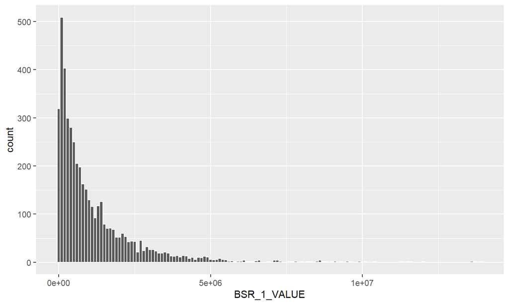

## ADS 1_1

[figure not shown]

## ADS 2_1

```
product_rank_hist_2_1 <- ggplot(amazon_dataset_2_delim_bsr_1st, aes(x=BSR_1_VALUE)) +
                                  geom_histogram(binwidth = 100000, color = "white")
print(product_rank_hist_2_1)
product_rank_dot_2_1 <- plot(Product_Price ~ BSR_1_VALUE, data = amazon_dataset_2_delim_bsr_1st)
coe_2_1 <- cor(amazon_dataset_2_delim_bsr_1st$Product_Price, amazon_dataset_2_delim_bsr_1st$BSR_1_VALUE)
print(coe_2_1)
```

## ADS 2_1

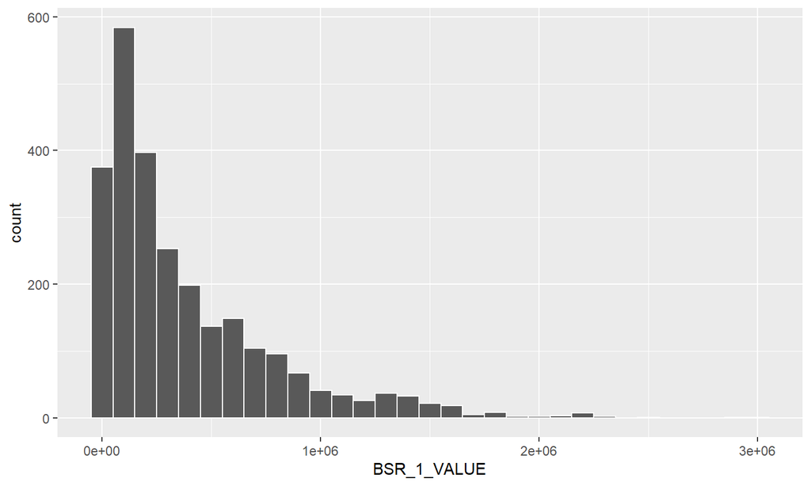

## ADS 2_1

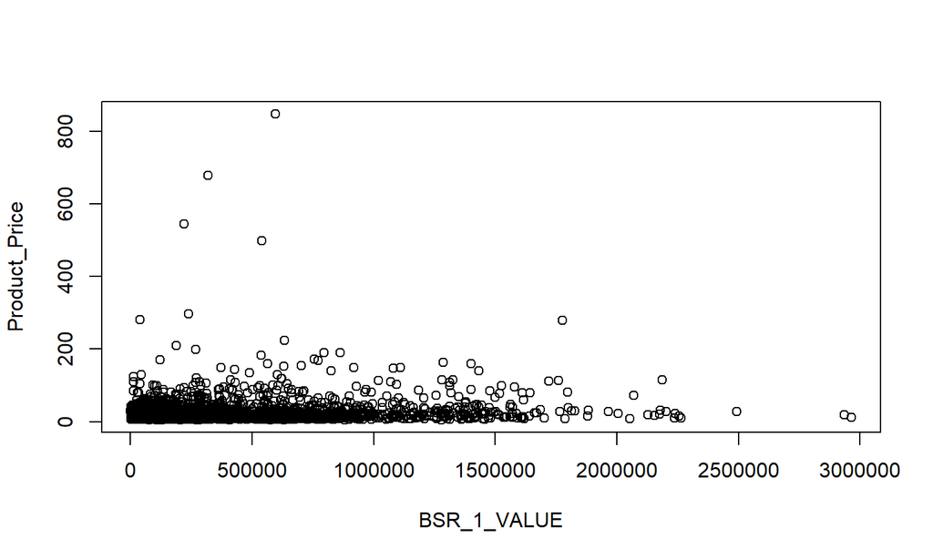

## ADS 2_1 COR.COE

[1] 0.1016072

> NO/NEGLIGIBLE RELATIONSHIP BETWEEN PRODUCT PRICE AND PRODUCT RANK IN DF2

# IT IS SAFE TO ASSUME THAT WITHIN THE ENTIRE DATASET, THERE IS NO RELATIONSHIP BETWEEN PRODUCT RANK AND PRODUCT PRICE

# PART 10 - RELATIONSHIP BETWEEN PRODUCT RATING AND PRODUCT RANK

## SUBSET OF VALUES WITH PRODUCT RATING AND RANK (REMOVE VALUES WITH NO RATINGS)

```
amazon_dataset_1_delim_bsr_rating <- drop_na(amazon_dataset_1_delim_bsr_1st, "Product_Reviews_Count")

amazon_dataset_1_delim_bsr_rating <- amazon_dataset_1_delim_bsr_rating[which(amazon_dataset_1_delim_bsr_rating$Product_Reviews_Count > 0),]
```

## SCATTER PLOT

```
plot(Product_Rating ~ BSR_1_VALUE, data = amazon_dataset_1_delim_bsr_rating)
```

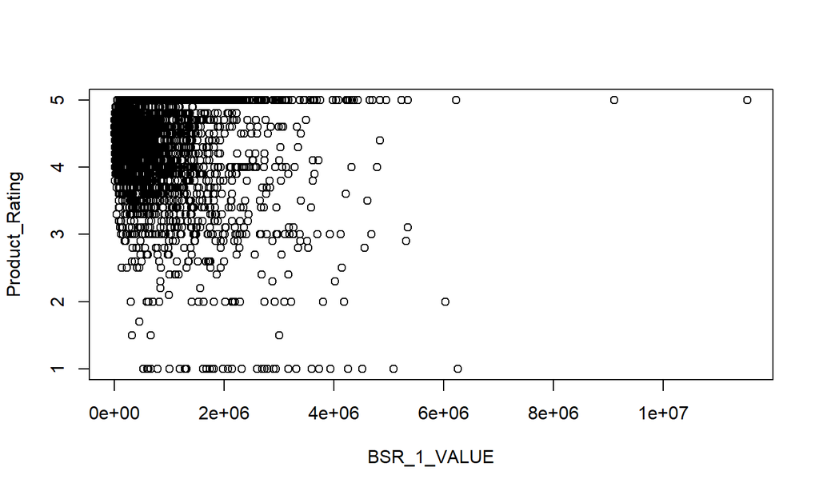

## COR.COE BETWEEN PRODUCT RANK AND PRODUCT RATING

```
coe_rating_rank <- cor(amazon_dataset_1_delim_bsr_rating$Product_Rating, amazon_dataset_1_delim_bsr_rating$BSR_1_VALUE)
print(coe_rating_rank)
```

[1] -0.1931606

## COR.COE BETWEEN PRODUCT RANK AND PRODUCT RATING

# FINAL OBSERVATIONS

## OTHER QUANTITATIVE OBSERVATIONS

- THE QUANTITATIVE OBSERVATIONS THAT WERE MADE HAD CLOSE TO NO CORRELATION BUT WE CAN SAY WITH SOME CERTAINTY THAT
- THE LACK OF RELATIONSHIP BETWEEN PRODUCT PRICE AND PRODUCT RATING IS ONE OF MANY INDICATORs THAT LOWER PRICING IS HIGHLY PRIORITIZED ON AMAZON AS OPPOSED TO PRODUCT QUALITY, BY BOTH CONSUMER AND VENDORS
- THAT PRODUCT PRICE AND RATING ARE ONLY TWO OF MANY RELATIONSHIPS THAT CONTRIBUTE TO PRODUCT RANKING ON AMAZON